# Homework II

## **6. (10 pts) Consider the Gini index, classification error, and entropy in a simple classification setting with two classes. Create a single plot using R that displays each of these quantities as a function of ˆpm1. Note that the x-axis should display ˆpm1, ranging from 0 to 1, and the y-axis should display the value of the error metrics.**

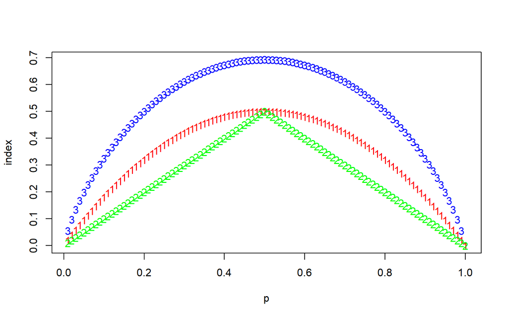

```r
p <- seq(0.01, 1, 0.01)
gini.index <- 2 * p * (1 - p)
class.error <- 1 - pmax(p, 1 - p)
cross.entropy <- - (p * log(p) + (1 - p) * log(1 - p))

matplot(p, cbind(gini.index, class.error, cross.entropy), col = c("red", "green", "blue"), ann = F)
title(ylab = "index", xlab = "p")
```

## **7. (30 pts) Use the house Values dataset of HW 1 and the basic model below (in R notation) to do the following:**

$VALUE ∼ AMMORT + EAPTBL + ECOM1 + ECOM2 + EGREEN + EJUNK + HOWH + ZINC2 + BATHS + BEDRMS$

**Note that before you get started, you should clean your data (remove NAs, remove observations with negative values for ZINC2 and VALUE). We have several dummy variables in the model and some numerical variables having large values. To better interpret your results, you can do log transformation of some (or all) numerical variables.**

### **(1) Use the best subset selection algorithm to select the best model. Report the number, name, and corresponding coefficients of the included variables. You can use one of the four assessment metrics (Cp, AIC, BIC, adjusted R2) to compare the models. Explain the assessment metric you choose and how it helps you decide the optimal model.**

**I have done log transformation to VALUE, ZINC2 and AMMORT**

```r
# best subset selection
regfit.full=regsubsets(VALUE ~.,hw2_data,nvmax=10)
reg.summary=summary(regfit.full)
```

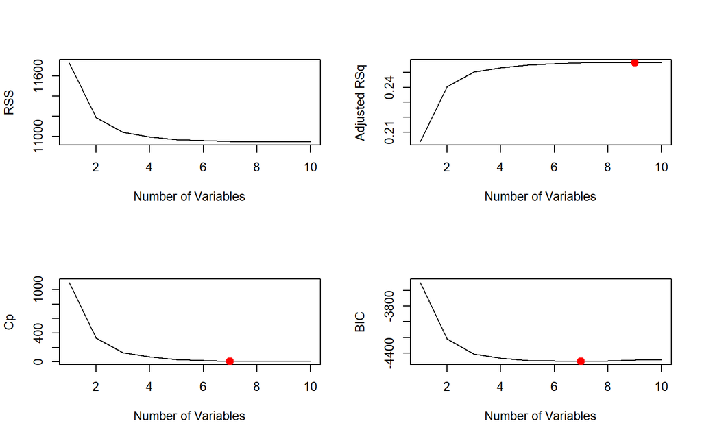

```r
par(mfrow=c(2,2))
plot(reg.summary$rss,xlab="Number of Variables",ylab="RSS",type="l") # residual sum of square
plot(reg.summary$adjr2,xlab="Number of Variables",ylab="Adjusted RSq",type="l") # adjusted R square, adjust for the number of predictors
points(9,reg.summary$adjr2[9], col="red",cex=2,pch=20) # cex--relative size, default = 1
plot(reg.summary$cp,xlab="Number of Variables",ylab="Cp",type='l') # 'l' type tells R to connect the point with the line.
points(7,reg.summary$cp[7],col="red",cex=2,pch=20)
plot(reg.summary$bic,xlab="Number of Variables",ylab="BIC",type='l')
points(7,reg.summary$bic[7],col="red",cex=2,pch=20)
```

```r
coef(regfit.full,id=7)
```

```
(Intercept)      AMMORT      ECOM2Y      EJUNKY    HOWHgood       ZINC2
  5.9725670   0.3600644  -0.1810750  -0.1895950   0.1526659   0.1053937
      BATHS      BEDRMS
  0.1955674   0.0720139
```

```r
coef(regfit.full,id=9)
```

```
(Intercept)      AMMORT      ECOM1Y      ECOM2Y     EGREENY      EJUNKY
 5.99117539  0.35926250 -0.02481534 -0.17145784  0.01879766 -0.18862171
   HOWHgood       ZINC2       BATHS      BEDRMS
 0.15153235  0.10477286  0.19386056  0.07164319
```

In terms of $C_p$ , BIC and AIC, the best model is:

$VALUE ∼ AMMORT + ECOM2 + EJUNK + HOWH + ZINC2 + BATHS + BEDRMS$

In terms of adjusted $R^2$, the best model is:

$VALUE ∼ AMMORT + ECOM1 + ECOM2 + EJUNK + EGREEN + HOWH + ZINC2 + BATHS + BEDRMS$

Explain the assessment metric you choose and how it helps you decide the optimal model.

All these assessment metric adjust the training error for the model size. These approaches can be used to select among a set of models with different numbers of variables. They put penalty to the number of predictors. The penalty increases as the number of predictors in the model increases; this is intended to adjust for the corresponding decrease in training RSS. By find the model with smallest $C_p$ , BIC, AIC or largest adjusted $R^2$ we can choose the optimal model.

### **(2) Use the forward stepwise selection algorithm to select the best model with 10 folds cross validation. Report the number, names, and corresponding coefficients of the included variables.**

```r
k=10
set.seed(10)
# ramdomly assign the observations into different folds
folds=sample(1:k,nrow(hw2_data),replace=TRUE)
cv.errors=matrix(NA,k,10, dimnames=list(NULL, paste(1:10))) # paste -- genereate character data
for(j in 1:k){
  forward.fit=regsubsets(VALUE~.,data=hw2_data[folds!=j,],nvmax=10,method="forward") # train the model
  for(i in 1:10){
    pred=predict.regsubsets(forward.fit,hw2_data[folds==j,],id=i) # test on the j-th subset
    cv.errors[j,i]=mean( (hw2_data$VALUE[folds==j]-pred)^2) # mean squared error, stored in the error matrix
  }
} # return 10x19 matrix
mean.cv.errors=apply(cv.errors,2,mean) # apply a function to margins of an array or matrix # mean by column
which.min(mean.cv.errors)
```

```
7
7
```

```r
forward.fit=regsubsets(VALUE~.,data=hw2_data,nvmax=10,method="forward")
coef(forward.fit,7)
```

```
(Intercept)      AMMORT      ECOM2Y      EJUNKY    HOWHgood       ZINC2
  5.9725670   0.3600644  -0.1810750  -0.1895950   0.1526659   0.1053937
      BATHS      BEDRMS
  0.1955674   0.0720139
```

### **(3) Use 10-fold cross validation to train the ridge model. Try different λ’s and report the best λ value. You should create the choice set of λ’s with at least 100 values.**

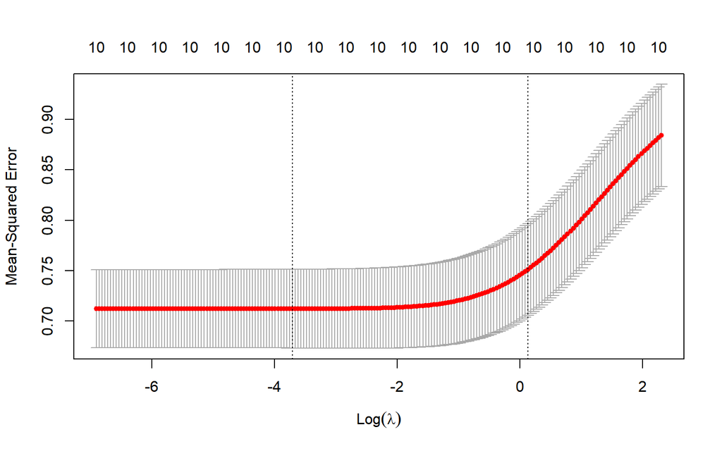

```r
grid=10^seq(1,-3,length=200)

RIDGE <- model.matrix(VALUE ~ ., data = hw2_data)[, -1]
cv.ridge <- cv.glmnet(RIDGE, hw2_data$VALUE, alpha = 0, nfolds = 10, lambda=grid)
plot(cv.ridge)
```

```r
bestlam <- cv.ridge$lambda.min
bestlam
```

```
[1] 0.02437444
```

```r
fit.ridge <- glmnet(RIDGE, hw2_data$VALUE, alpha = 0)
predict(fit.ridge, s = bestlam, type = "coefficients")[1:11, ]
```

```
  (Intercept)        AMMORT       EAPTBLY        ECOM1Y        ECOM2Y
 6.1598685603  0.3439372703  0.0007267058 -0.0277503558 -0.1686332826
      EGREENY        EJUNKY      HOWHgood         ZINC2         BATHS
 0.0205002622 -0.1878347979  0.1503788974  0.1054747655  0.1900548021
       BEDRMS
 0.0738078178
```

### (4) Use 10-fold cross validation to train the lasso model. Try different λ’s and report the best λ value. You should create the choice set of λ’s with at least 100 values. Plot the graph that shows how the MSE changes with λ. Report the coefficients of the variables in the best model and interpret your results.

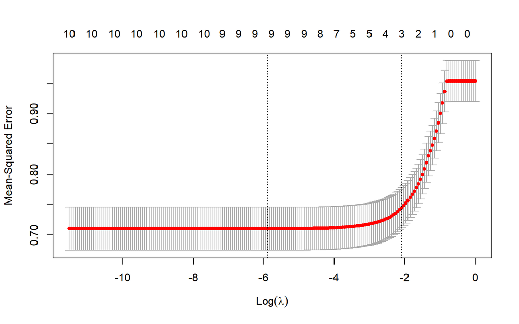

```r
grid=10^seq(0,-5,length=200)
LASSO <- model.matrix(VALUE ~ ., data = hw2_data)[, -1]
cv.lasso <- cv.glmnet(LASSO, hw2_data$VALUE, alpha = 1, nfolds = 10, lambda=grid)
plot(cv.lasso)
```

```r
bestlam <- cv.lasso$lambda.min
bestlam
```

```
[1] 0.00273644
```

```r
fit.lasso <- glmnet(LASSO, hw2_data$VALUE, alpha = 1)
predict(fit.lasso, s = bestlam, type = "coefficients")[1:11, ]
```

```
(Intercept)      AMMORT     EAPTBLY      ECOM1Y      ECOM2Y     EGREENY
 6.03365917  0.35808405  0.00000000 -0.02021984 -0.15671273  0.01348732
     EJUNKY    HOWHgood       ZINC2       BATHS      BEDRMS
-0.17114269  0.14422944  0.10334488  0.19335583  0.07012672
```

The lasso method picks all variables except EAPTBL for the model.

### (5) Compare the best models you obtained in (1), (2), (3), and (4), what do you find? (For example, how many variables are included in each model? the coefficients?)

When use best subset and select 7-predictors model according to $C_p$ , BIC and AIC, the model is the same as the model we choose using forward subset.

When use best subset and select 9-predictors model according to adjusted $R^2$, the model has the same predictors as lasso model, but the coef of lasso model is slightly smaller.

Ridge model use all 10-pridectors but the model is very similar to these two 9-predictors models above, the coef of the only different predictor(EAPTBL) is very small(0.0007267058).